# African Eco pro(final)

Africa Economic, Banking and Systemic Crisis Data About Dataset Context This dataset is a derivative of Reinhart et. al's Global Financial Stability dataset which can be found online at: https://www.hbs.edu/behavioral-finance-and-financial-stability/data/Pages/global.aspx

The dataset will be valuable to those who seek to understand the dynamics of financial stability within the African context.

Content The dataset specifically focuses on the Banking, Debt, Financial, Inflation and Systemic Crises that occurred, from 1860 to 2014, in 13 African countries, including: Algeria, Angola, Central African Republic, Ivory Coast, Egypt, Kenya, Mauritius, Morocco, Nigeria, South Africa, Tunisia, Zambia and Zimbabwe.

Acknowledgements Reinhart, C., Rogoff, K., Trebesch, C. and Reinhart, V. (2019) Global Crises Data by Country. [online] https://www.hbs.edu/behavioral-finance-and-financial-stability/data. Available at: https://www.hbs.edu/behavioral-finance-and-financial-stability/data/Pages/global.aspx [Accessed: 17 July 2019].

Inspiration My inspiration stems from two questions: "Which factors are most associated with Systemic Crises in Africa?" And; "At which annual rate of inflation does an Inflation Crisis become a practical certainty?"

Usability 10.00

License Data files © Original Authors

Expected update frequency Never Tags Business Finance Economics Banking History Africa

```python
# Import libraries
import pandas as pd
import numpy as np
import matplotlib.pyplot as plt
%matplotlib inline
import seaborn as sns
```

```python
# upload dataset:
df= pd.read_csv("F:\\archive (12)\\african_crises.csv")
df.head(2)
```

|  | case | cc3 | country | year | systemic_crisis | exch_usd | domestic_debt_in_default | sovereign_external_debt_default | gdp_weighted_default | inflation_annual_cpi | independence | currency_crises | inflation_crises | banking_crisis |
| --- | --- | --- | --- | --- | --- | --- | --- | --- | --- | --- | --- | --- | --- | --- |
| 0 | 1 | DZA | Algeria | 1870 | 1 | 0.052264 | 0 | 0 | 0.0 | 3.441456 | 0 | 0 | 0 | crisis |
| 1 | 1 | DZA | Algeria | 1871 | 0 | 0.052798 | 0 | 0 | 0.0 | 14.149140 | 0 | 0 | 0 | no_crisis |

```python
# give the spaces at the end
print(df.columns, end=" ")
```

```
Index(['case', 'cc3', 'country', 'year', 'systemic_crisis', 'exch_usd',
       'domestic_debt_in_default', 'sovereign_external_debt_default',
       'gdp_weighted_default', 'inflation_annual_cpi', 'independence',
       'currency_crises', 'inflation_crises', 'banking_crisis'],
      dtype='object')
```

```python
# see the first five rows of data:
df.head(5)
```

|  | case | cc3 | country | year | systemic_crisis | exch_usd | domestic_debt_in_default | sovereign_external_debt_default | gdp_weighted_default | inflation_annual_cpi | independence | currency_crises | inflation_crises | banking_crisis |
| --- | --- | --- | --- | --- | --- | --- | --- | --- | --- | --- | --- | --- | --- | --- |
| 0 | 1 | DZA | Algeria | 1870 | 1 | 0.052264 | 0 | 0 | 0.0 | 3.441456 | 0 | 0 | 0 | crisis |
| 1 | 1 | DZA | Algeria | 1871 | 0 | 0.052798 | 0 | 0 | 0.0 | 14.149140 | 0 | 0 | 0 | no_crisis |
| 2 | 1 | DZA | Algeria | 1872 | 0 | 0.052274 | 0 | 0 | 0.0 | -3.718593 | 0 | 0 | 0 | no_crisis |
| 3 | 1 | DZA | Algeria | 1873 | 0 | 0.051680 | 0 | 0 | 0.0 | 11.203897 | 0 | 0 | 0 | no_crisis |
| 4 | 1 | DZA | Algeria | 1874 | 0 | 0.051308 | 0 | 0 | 0.0 | -3.848561 | 0 | 0 | 0 | no_crisis |

```python
# To see the bottm five rows of data
df.tail(5)
```

|  | case | cc3 | country | year | systemic_crisis | exch_usd | domestic_debt_in_default | sovereign_external_debt_default | gdp_weighted_default | inflation_annual_cpi | independence | currency_crises | inflation_crises | banking_crisis |
| --- | --- | --- | --- | --- | --- | --- | --- | --- | --- | --- | --- | --- | --- | --- |
| 1054 | 70 | ZWE | Zimbabwe | 2009 | 1 | 354.8 | 1 | 1 | 0.0 | -7.670 | 1 | 1 | 0 | crisis |
| 1055 | 70 | ZWE | Zimbabwe | 2010 | 0 | 378.2 | 1 | 1 | 0.0 | 3.217 | 1 | 0 | 0 | no_crisis |
| 1056 | 70 | ZWE | Zimbabwe | 2011 | 0 | 361.9 | 1 | 1 | 0.0 | 4.920 | 1 | 0 | 0 | no_crisis |
| 1057 | 70 | ZWE | Zimbabwe | 2012 | 0 | 361.9 | 1 | 1 | 0.0 | 3.720 | 1 | 0 | 0 | no_crisis |
| 1058 | 70 | ZWE | Zimbabwe | 2013 | 0 | 361.9 | 1 | 1 | 0.0 | 1.632 | 1 | 0 | 0 | no_crisis |

```python
# To see the shape of data:
df.shape
```

```
(1059, 14)
```

```python
# To see the size of data:
df.size
```

```
14826
```

```python
# To see the columns of data :
df.columns
```

```
Index(['case', 'cc3', 'country', 'year', 'systemic_crisis', 'exch_usd',
       'domestic_debt_in_default', 'sovereign_external_debt_default',
       'gdp_weighted_default', 'inflation_annual_cpi', 'independence',
       'currency_crises', 'inflation_crises', 'banking_crisis'],
      dtype='object')
```

```python
# give the infomation of data :
df.info()
```

```
<class 'pandas.core.frame.DataFrame'>
RangeIndex: 1059 entries, 0 to 1058
Data columns (total 14 columns):
 #   Column                           Non-Null Count  Dtype
---  ------                           --------------  -----
 0   case                             1059 non-null   int64
 1   cc3                              1059 non-null   object
 2   country                          1059 non-null   object
 3   year                             1059 non-null   int64
 4   systemic_crisis                  1059 non-null   int64
 5   exch_usd                         1059 non-null   float64
 6   domestic_debt_in_default         1059 non-null   int64
 7   sovereign_external_debt_default  1059 non-null   int64
 8   gdp_weighted_default             1059 non-null   float64
 9   inflation_annual_cpi             1059 non-null   float64
 10  independence                     1059 non-null   int64
 11  currency_crises                  1059 non-null   int64
 12  inflation_crises                 1059 non-null   int64
 13  banking_crisis                   1059 non-null   object
dtypes: float64(3), int64(8), object(3)
memory usage: 116.0+ KB
```

```python
# To see the statiscal summary or descrption of data:
df.describe
```

[output not shown]

[output cut: 38 more lines]

```python
# see the null values whether it is present in data or not, there is no null values so no further null
# values treatment is required :
df.isnull().sum()
```

```
case                               0
cc3                                0
country                            0
year                               0
systemic_crisis                    0
exch_usd                           0
domestic_debt_in_default           0
sovereign_external_debt_default    0
gdp_weighted_default               0
inflation_annual_cpi               0
independence                       0
currency_crises                    0
inflation_crises                   0
banking_crisis                     0
dtype: int64
```

```python
# To see the data types in the data , whether integer, float or an object:
df.dtypes
```

```
case                                 int64
cc3                                 object
country                             object
year                                 int64
systemic_crisis                      int64
exch_usd                           float64
domestic_debt_in_default             int64
sovereign_external_debt_default      int64
gdp_weighted_default               float64
inflation_annual_cpi               float64
independence                         int64
currency_crises                      int64
inflation_crises                     int64
banking_crisis                      object
dtype: object
```

```python
# To finding the unique values of country column in data , it makes an array of listing countries in
# the data:
df.country.unique()
```

```
array(['Algeria', 'Angola', 'Central African Republic', 'Ivory Coast',
       'Egypt', 'Kenya', 'Mauritius', 'Morocco', 'Nigeria',
       'South Africa', 'Tunisia', 'Zambia', 'Zimbabwe'], dtype=object)
```

```python
# To see the two important columns together for comparison:
df[['country', 'year']]
```

|  | country | year |
| --- | --- | --- |
| 0 | Algeria | 1870 |
| 1 | Algeria | 1871 |
| 2 | Algeria | 1872 |
| 3 | Algeria | 1873 |
| 4 | Algeria | 1874 |
| ... | ... | ... |
| 1054 | Zimbabwe | 2009 |
| 1055 | Zimbabwe | 2010 |
| 1056 | Zimbabwe | 2011 |
| 1057 | Zimbabwe | 2012 |
| 1058 | Zimbabwe | 2013 |

1059 rows × 2 columns

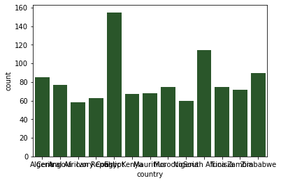

```python
# Make a countplot of important variable like country is here...
sns.countplot(x='country',data=df, color='green', saturation=0.35)
```

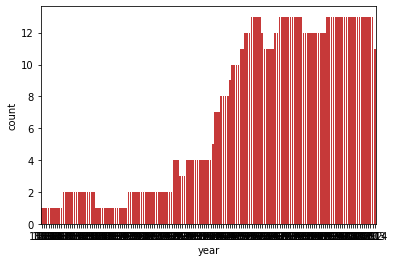

```python
# Make a countplot of year, one of the important variable of data...
sns.countplot(x='year',data=df, color='red', saturation=0.55)
```